# Risk Factor Analysis

## Outcome Variable

**Outcome Variable:** y_rate_wtkg

## Predictor Variables

**Intervention Variable:** predfeed6

**Adjustment Set:**

unadjusted

## Stratifying Variables

The analysis was stratified on these variable(s):

- agecat
- studyid
- country

## Data Summary

| agecat | studyid | country | predfeed6 | n_cell | n |
| --- | --- | --- | --- | --- | --- |
| 0-3 months | ki0047075b-MAL-ED | BANGLADESH | 1 | 84 | 230 |
| 0-3 months | ki0047075b-MAL-ED | BANGLADESH | 0 | 146 | 230 |
| 0-3 months | ki0047075b-MAL-ED | BRAZIL | 1 | 30 | 210 |
| 0-3 months | ki0047075b-MAL-ED | BRAZIL | 0 | 180 | 210 |
| 0-3 months | ki0047075b-MAL-ED | INDIA | 1 | 11 | 216 |
| 0-3 months | ki0047075b-MAL-ED | INDIA | 0 | 205 | 216 |
| 0-3 months | ki0047075b-MAL-ED | NEPAL | 1 | 11 | 219 |
| 0-3 months | ki0047075b-MAL-ED | NEPAL | 0 | 208 | 219 |
| 0-3 months | ki0047075b-MAL-ED | PERU | 1 | 92 | 270 |
| 0-3 months | ki0047075b-MAL-ED | PERU | 0 | 178 | 270 |
| 0-3 months | ki0047075b-MAL-ED | SOUTH AFRICA | 1 | 3 | 234 |
| 0-3 months | ki0047075b-MAL-ED | SOUTH AFRICA | 0 | 231 | 234 |
| 0-3 months | ki0047075b-MAL-ED | TANZANIA, UNITED REPUBLIC OF | 1 | 1 | 219 |
| 0-3 months | ki0047075b-MAL-ED | TANZANIA, UNITED REPUBLIC OF | 0 | 218 | 219 |
| 0-3 months | ki1000109-EE | PAKISTAN | 1 | 35 | 39 |
| 0-3 months | ki1000109-EE | PAKISTAN | 0 | 4 | 39 |
| 0-3 months | ki1113344-GMS-Nepal | NEPAL | 1 | 368 | 501 |
| 0-3 months | ki1113344-GMS-Nepal | NEPAL | 0 | 133 | 501 |
| 0-3 months | kiGH5241-JiVitA-3 | BANGLADESH | 1 | 4688 | 6036 |
| 0-3 months | kiGH5241-JiVitA-3 | BANGLADESH | 0 | 1348 | 6036 |
| 0-3 months | kiGH5241-JiVitA-4 | BANGLADESH | 1 | 534 | 619 |
| 0-3 months | kiGH5241-JiVitA-4 | BANGLADESH | 0 | 85 | 619 |
| 3-6 months | ki0047075b-MAL-ED | BANGLADESH | 1 | 81 | 224 |
| 3-6 months | ki0047075b-MAL-ED | BANGLADESH | 0 | 143 | 224 |
| 3-6 months | ki0047075b-MAL-ED | BRAZIL | 1 | 30 | 208 |
| 3-6 months | ki0047075b-MAL-ED | BRAZIL | 0 | 178 | 208 |
| 3-6 months | ki0047075b-MAL-ED | INDIA | 1 | 11 | 213 |
| 3-6 months | ki0047075b-MAL-ED | INDIA | 0 | 202 | 213 |
| 3-6 months | ki0047075b-MAL-ED | NEPAL | 1 | 11 | 222 |
| 3-6 months | ki0047075b-MAL-ED | NEPAL | 0 | 211 | 222 |

[output cut: 150 more lines]

The following strata were considered:

- agecat: 0-3 months, studyid: ki0047075b-MAL-ED, country: BANGLADESH
- agecat: 0-3 months, studyid: ki0047075b-MAL-ED, country: BRAZIL
- agecat: 0-3 months, studyid: ki0047075b-MAL-ED, country: INDIA
- agecat: 0-3 months, studyid: ki0047075b-MAL-ED, country: NEPAL
- agecat: 0-3 months, studyid: ki0047075b-MAL-ED, country: PERU
- agecat: 0-3 months, studyid: ki0047075b-MAL-ED, country: SOUTH AFRICA
- agecat: 0-3 months, studyid: ki0047075b-MAL-ED, country: TANZANIA, UNITED REPUBLIC OF
- agecat: 0-3 months, studyid: ki1000109-EE, country: PAKISTAN
- agecat: 0-3 months, studyid: ki1113344-GMS-Nepal, country: NEPAL
- agecat: 0-3 months, studyid: kiGH5241-JiVitA-3, country: BANGLADESH
- agecat: 0-3 months, studyid: kiGH5241-JiVitA-4, country: BANGLADESH
- agecat: 12-15 months, studyid: ki0047075b-MAL-ED, country: BANGLADESH
- agecat: 12-15 months, studyid: ki0047075b-MAL-ED, country: BRAZIL
- agecat: 12-15 months, studyid: ki0047075b-MAL-ED, country: INDIA
- agecat: 12-15 months, studyid: ki0047075b-MAL-ED, country: NEPAL
- agecat: 12-15 months, studyid: ki0047075b-MAL-ED, country: PERU
- agecat: 12-15 months, studyid: ki0047075b-MAL-ED, country: SOUTH AFRICA
- agecat: 12-15 months, studyid: ki0047075b-MAL-ED, country: TANZANIA, UNITED REPUBLIC OF
- agecat: 12-15 months, studyid: ki1000109-EE, country: PAKISTAN
- agecat: 12-15 months, studyid: ki1000304b-SAS-FoodSuppl, country: INDIA
- agecat: 12-15 months, studyid: ki1113344-GMS-Nepal, country: NEPAL
- agecat: 12-15 months, studyid: ki1148112-LCNI-5, country: MALAWI
- agecat: 12-15 months, studyid: kiGH5241-JiVitA-4, country: BANGLADESH
- agecat: 15-18 months, studyid: ki0047075b-MAL-ED, country: BANGLADESH
- agecat: 15-18 months, studyid: ki0047075b-MAL-ED, country: BRAZIL
- agecat: 15-18 months, studyid: ki0047075b-MAL-ED, country: INDIA
- agecat: 15-18 months, studyid: ki0047075b-MAL-ED, country: NEPAL
- agecat: 15-18 months, studyid: ki0047075b-MAL-ED, country: PERU
- agecat: 15-18 months, studyid: ki0047075b-MAL-ED, country: SOUTH AFRICA
- agecat: 15-18 months, studyid: ki0047075b-MAL-ED, country: TANZANIA, UNITED REPUBLIC OF
- agecat: 15-18 months, studyid: ki1000109-EE, country: PAKISTAN
- agecat: 15-18 months, studyid: ki1000304b-SAS-FoodSuppl, country: INDIA
- agecat: 15-18 months, studyid: ki1113344-GMS-Nepal, country: NEPAL
- agecat: 15-18 months, studyid: ki1148112-LCNI-5, country: MALAWI
- agecat: 15-18 months, studyid: kiGH5241-JiVitA-4, country: BANGLADESH
- agecat: 18-21 months, studyid: ki0047075b-MAL-ED, country: BANGLADESH
- agecat: 18-21 months, studyid: ki0047075b-MAL-ED, country: BRAZIL
- agecat: 18-21 months, studyid: ki0047075b-MAL-ED, country: INDIA
- agecat: 18-21 months, studyid: ki0047075b-MAL-ED, country: NEPAL
- agecat: 18-21 months, studyid: ki0047075b-MAL-ED, country: PERU
- agecat: 18-21 months, studyid: ki0047075b-MAL-ED, country: SOUTH AFRICA
- agecat: 18-21 months, studyid: ki0047075b-MAL-ED, country: TANZANIA, UNITED REPUBLIC OF
- agecat: 18-21 months, studyid: ki1000109-EE, country: PAKISTAN
- agecat: 18-21 months, studyid: ki1113344-GMS-Nepal, country: NEPAL
- agecat: 18-21 months, studyid: ki1148112-LCNI-5, country: MALAWI
- agecat: 21-24 months, studyid: ki0047075b-MAL-ED, country: BANGLADESH
- agecat: 21-24 months, studyid: ki0047075b-MAL-ED, country: BRAZIL
- agecat: 21-24 months, studyid: ki0047075b-MAL-ED, country: INDIA
- agecat: 21-24 months, studyid: ki0047075b-MAL-ED, country: NEPAL
- agecat: 21-24 months, studyid: ki0047075b-MAL-ED, country: PERU
- agecat: 21-24 months, studyid: ki0047075b-MAL-ED, country: SOUTH AFRICA
- agecat: 21-24 months, studyid: ki0047075b-MAL-ED, country: TANZANIA, UNITED REPUBLIC OF
- agecat: 21-24 months, studyid: ki1000109-EE, country: PAKISTAN
- agecat: 21-24 months, studyid: ki1113344-GMS-Nepal, country: NEPAL
- agecat: 21-24 months, studyid: ki1148112-LCNI-5, country: MALAWI
- agecat: 3-6 months, studyid: ki0047075b-MAL-ED, country: BANGLADESH
- agecat: 3-6 months, studyid: ki0047075b-MAL-ED, country: BRAZIL
- agecat: 3-6 months, studyid: ki0047075b-MAL-ED, country: INDIA
- agecat: 3-6 months, studyid: ki0047075b-MAL-ED, country: NEPAL
- agecat: 3-6 months, studyid: ki0047075b-MAL-ED, country: PERU
- agecat: 3-6 months, studyid: ki0047075b-MAL-ED, country: SOUTH AFRICA
- agecat: 3-6 months, studyid: ki0047075b-MAL-ED, country: TANZANIA, UNITED REPUBLIC OF
- agecat: 3-6 months, studyid: ki1000109-EE, country: PAKISTAN
- agecat: 3-6 months, studyid: ki1113344-GMS-Nepal, country: NEPAL
- agecat: 3-6 months, studyid: kiGH5241-JiVitA-3, country: BANGLADESH
- agecat: 3-6 months, studyid: kiGH5241-JiVitA-4, country: BANGLADESH
- agecat: 6-9 months, studyid: ki0047075b-MAL-ED, country: BANGLADESH
- agecat: 6-9 months, studyid: ki0047075b-MAL-ED, country: BRAZIL
- agecat: 6-9 months, studyid: ki0047075b-MAL-ED, country: INDIA
- agecat: 6-9 months, studyid: ki0047075b-MAL-ED, country: NEPAL
- agecat: 6-9 months, studyid: ki0047075b-MAL-ED, country: PERU
- agecat: 6-9 months, studyid: ki0047075b-MAL-ED, country: SOUTH AFRICA
- agecat: 6-9 months, studyid: ki0047075b-MAL-ED, country: TANZANIA, UNITED REPUBLIC OF
- agecat: 6-9 months, studyid: ki1000109-EE, country: PAKISTAN
- agecat: 6-9 months, studyid: ki1000304b-SAS-FoodSuppl, country: INDIA
- agecat: 6-9 months, studyid: ki1113344-GMS-Nepal, country: NEPAL
- agecat: 6-9 months, studyid: ki1148112-LCNI-5, country: MALAWI
- agecat: 6-9 months, studyid: kiGH5241-JiVitA-4, country: BANGLADESH
- agecat: 9-12 months, studyid: ki0047075b-MAL-ED, country: BANGLADESH
- agecat: 9-12 months, studyid: ki0047075b-MAL-ED, country: BRAZIL
- agecat: 9-12 months, studyid: ki0047075b-MAL-ED, country: INDIA
- agecat: 9-12 months, studyid: ki0047075b-MAL-ED, country: NEPAL
- agecat: 9-12 months, studyid: ki0047075b-MAL-ED, country: PERU
- agecat: 9-12 months, studyid: ki0047075b-MAL-ED, country: SOUTH AFRICA
- agecat: 9-12 months, studyid: ki0047075b-MAL-ED, country: TANZANIA, UNITED REPUBLIC OF
- agecat: 9-12 months, studyid: ki1000109-EE, country: PAKISTAN
- agecat: 9-12 months, studyid: ki1000304b-SAS-FoodSuppl, country: INDIA
- agecat: 9-12 months, studyid: ki1113344-GMS-Nepal, country: NEPAL
- agecat: 9-12 months, studyid: ki1148112-LCNI-5, country: MALAWI
- agecat: 9-12 months, studyid: kiGH5241-JiVitA-4, country: BANGLADESH

### Dropped Strata

Some strata were dropped due to rare outcomes:

- agecat: 0-3 months, studyid: ki0047075b-MAL-ED, country: SOUTH AFRICA
- agecat: 0-3 months, studyid: ki0047075b-MAL-ED, country: TANZANIA, UNITED REPUBLIC OF
- agecat: 0-3 months, studyid: ki1000109-EE, country: PAKISTAN
- agecat: 3-6 months, studyid: ki0047075b-MAL-ED, country: SOUTH AFRICA
- agecat: 3-6 months, studyid: ki0047075b-MAL-ED, country: TANZANIA, UNITED REPUBLIC OF
- agecat: 3-6 months, studyid: ki1000109-EE, country: PAKISTAN
- agecat: 6-9 months, studyid: ki0047075b-MAL-ED, country: SOUTH AFRICA
- agecat: 6-9 months, studyid: ki0047075b-MAL-ED, country: TANZANIA, UNITED REPUBLIC OF
- agecat: 6-9 months, studyid: ki1000304b-SAS-FoodSuppl, country: INDIA
- agecat: 9-12 months, studyid: ki0047075b-MAL-ED, country: SOUTH AFRICA
- agecat: 9-12 months, studyid: ki0047075b-MAL-ED, country: TANZANIA, UNITED REPUBLIC OF
- agecat: 9-12 months, studyid: ki1000304b-SAS-FoodSuppl, country: INDIA
- agecat: 12-15 months, studyid: ki0047075b-MAL-ED, country: SOUTH AFRICA
- agecat: 12-15 months, studyid: ki0047075b-MAL-ED, country: TANZANIA, UNITED REPUBLIC OF
- agecat: 12-15 months, studyid: ki1000304b-SAS-FoodSuppl, country: INDIA
- agecat: 12-15 months, studyid: ki1148112-LCNI-5, country: MALAWI
- agecat: 15-18 months, studyid: ki0047075b-MAL-ED, country: SOUTH AFRICA
- agecat: 15-18 months, studyid: ki0047075b-MAL-ED, country: TANZANIA, UNITED REPUBLIC OF
- agecat: 15-18 months, studyid: ki1000304b-SAS-FoodSuppl, country: INDIA
- agecat: 15-18 months, studyid: ki1148112-LCNI-5, country: MALAWI
- agecat: 18-21 months, studyid: ki0047075b-MAL-ED, country: SOUTH AFRICA
- agecat: 18-21 months, studyid: ki0047075b-MAL-ED, country: TANZANIA, UNITED REPUBLIC OF
- agecat: 21-24 months, studyid: ki0047075b-MAL-ED, country: SOUTH AFRICA
- agecat: 21-24 months, studyid: ki0047075b-MAL-ED, country: TANZANIA, UNITED REPUBLIC OF
- agecat: 21-24 months, studyid: ki1000109-EE, country: PAKISTAN

## Methods Detail

We’re interested in the causal parameters $E[Y_a]$ for all values of $a \in \mathcal{A}$. These parameters represent the mean outcome if, possibly contrary to fact, we intervened to set all units to have $A=a$. Under the randomization and positivity assumptions, these are identified by the statistical parameters $\psi_a=E_W[E_{Y|A,W}(Y|A=a,W)]$. In addition, we’re interested in the mean of $Y$, $E[Y]$ under no intervention (the observed mean). We will estimate these parameters by using SuperLearner to fit the relevant likelihood factors – $E_{Y|A,W}(Y|A=a,W)$ and $p(A=a|W)$, and then updating our likelihood fit using a joint TMLE.

For unadjusted analyses ($W=\{\}$), initial likelihoods were estimated using Lrnr_glm to estimate the simple $E(Y|A)$ and Lrnr_mean to estimate $p(A)$. For adjusted analyses, a small library containing Lrnr_glmnet, Lrnr_xgboost, and Lrnr_mean was used.

Having estimated these parameters, we will then use the delta method to estimate relative risks and attributable risks relative to a prespecified baseline level of $A$.

# Results Detail

## Results Plots

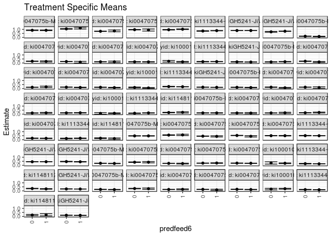

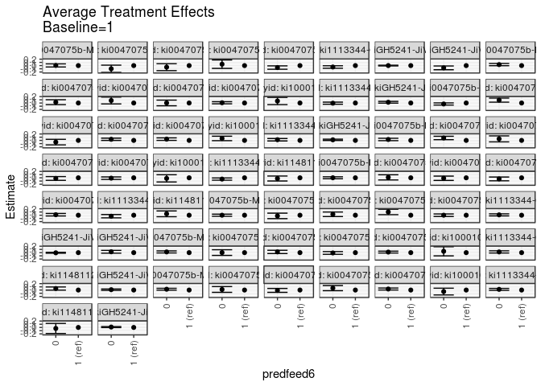

[figure not shown]

## Results Table

### Parameter: TSM

| agecat | studyid | country | intervention_level | baseline_level | estimate | ci_lower | ci_upper |
| --- | --- | --- | --- | --- | --- | --- | --- |
| 0-3 months | ki0047075b-MAL-ED | BANGLADESH | 1 | NA | 0.8785628 | 0.8416938 | 0.9154318 |
| 0-3 months | ki0047075b-MAL-ED | BANGLADESH | 0 | NA | 0.8832152 | 0.8515297 | 0.9149007 |
| 0-3 months | ki0047075b-MAL-ED | BRAZIL | 1 | NA | 1.1558074 | 1.0486772 | 1.2629375 |
| 0-3 months | ki0047075b-MAL-ED | BRAZIL | 0 | NA | 1.0560334 | 1.0200107 | 1.0920561 |
| 0-3 months | ki0047075b-MAL-ED | INDIA | 1 | NA | 0.8084220 | 0.7032785 | 0.9135655 |
| 0-3 months | ki0047075b-MAL-ED | INDIA | 0 | NA | 0.7590105 | 0.7352261 | 0.7827950 |
| 0-3 months | ki0047075b-MAL-ED | NEPAL | 1 | NA | 0.9156871 | 0.7869751 | 1.0443990 |
| 0-3 months | ki0047075b-MAL-ED | NEPAL | 0 | NA | 0.9592764 | 0.9310824 | 0.9874703 |
| 0-3 months | ki0047075b-MAL-ED | PERU | 1 | NA | 1.0127375 | 0.9713286 | 1.0541465 |
| 0-3 months | ki0047075b-MAL-ED | PERU | 0 | NA | 0.9513375 | 0.9188603 | 0.9838147 |
| 0-3 months | ki1113344-GMS-Nepal | NEPAL | 1 | NA | 0.8380598 | 0.8184064 | 0.8577132 |
| 0-3 months | ki1113344-GMS-Nepal | NEPAL | 0 | NA | 0.7935141 | 0.7595044 | 0.8275237 |
| 0-3 months | kiGH5241-JiVitA-3 | BANGLADESH | 1 | NA | 0.8494097 | 0.8439252 | 0.8548942 |
| 0-3 months | kiGH5241-JiVitA-3 | BANGLADESH | 0 | NA | 0.8500569 | 0.8403050 | 0.8598087 |
| 0-3 months | kiGH5241-JiVitA-4 | BANGLADESH | 1 | NA | 0.7639805 | 0.7375216 | 0.7904393 |
| 0-3 months | kiGH5241-JiVitA-4 | BANGLADESH | 0 | NA | 0.6931770 | 0.6413689 | 0.7449850 |
| 3-6 months | ki0047075b-MAL-ED | BANGLADESH | 1 | NA | 0.4750852 | 0.4505769 | 0.4995936 |
| 3-6 months | ki0047075b-MAL-ED | BANGLADESH | 0 | NA | 0.4753901 | 0.4525230 | 0.4982572 |
| 3-6 months | ki0047075b-MAL-ED | BRAZIL | 1 | NA | 0.5961292 | 0.5179612 | 0.6742971 |
| 3-6 months | ki0047075b-MAL-ED | BRAZIL | 0 | NA | 0.5751754 | 0.5411657 | 0.6091850 |
| 3-6 months | ki0047075b-MAL-ED | INDIA | 1 | NA | 0.4144199 | 0.3458150 | 0.4830248 |
| 3-6 months | ki0047075b-MAL-ED | INDIA | 0 | NA | 0.4436972 | 0.4251801 | 0.4622143 |
| 3-6 months | ki0047075b-MAL-ED | NEPAL | 1 | NA | 0.4244115 | 0.3419385 | 0.5068846 |
| 3-6 months | ki0047075b-MAL-ED | NEPAL | 0 | NA | 0.5262982 | 0.5051556 | 0.5474409 |
| 3-6 months | ki0047075b-MAL-ED | PERU | 1 | NA | 0.4984367 | 0.4667109 | 0.5301626 |
| 3-6 months | ki0047075b-MAL-ED | PERU | 0 | NA | 0.4988030 | 0.4750985 | 0.5225075 |
| 3-6 months | ki1113344-GMS-Nepal | NEPAL | 1 | NA | 0.4938217 | 0.4779042 | 0.5097393 |
| 3-6 months | ki1113344-GMS-Nepal | NEPAL | 0 | NA | 0.5053164 | 0.4771995 | 0.5334333 |
| 3-6 months | kiGH5241-JiVitA-3 | BANGLADESH | 1 | NA | 0.4449116 | 0.4391140 | 0.4507093 |
| 3-6 months | kiGH5241-JiVitA-3 | BANGLADESH | 0 | NA | 0.4396354 | 0.4269747 | 0.4522961 |

[output cut: 100 more lines]

### Parameter: E(Y)

| agecat | studyid | country | intervention_level | baseline_level | estimate | ci_lower | ci_upper |
| --- | --- | --- | --- | --- | --- | --- | --- |
| 0-3 months | ki0047075b-MAL-ED | BANGLADESH | NA | NA | 0.8815161 | 0.8573098 | 0.9057224 |
| 0-3 months | ki0047075b-MAL-ED | BRAZIL | NA | NA | 1.0702868 | 1.0355019 | 1.1050717 |
| 0-3 months | ki0047075b-MAL-ED | INDIA | NA | NA | 0.7615268 | 0.7382819 | 0.7847718 |
| 0-3 months | ki0047075b-MAL-ED | NEPAL | NA | NA | 0.9570869 | 0.9295107 | 0.9846631 |
| 0-3 months | ki0047075b-MAL-ED | PERU | NA | NA | 0.9722590 | 0.9463823 | 0.9981357 |
| 0-3 months | ki1113344-GMS-Nepal | NEPAL | NA | NA | 0.8262343 | 0.8091204 | 0.8433482 |
| 0-3 months | kiGH5241-JiVitA-3 | BANGLADESH | NA | NA | 0.8495542 | 0.8446145 | 0.8544939 |
| 0-3 months | kiGH5241-JiVitA-4 | BANGLADESH | NA | NA | 0.7542578 | 0.7300866 | 0.7784291 |
| 3-6 months | ki0047075b-MAL-ED | BANGLADESH | NA | NA | 0.4752798 | 0.4582021 | 0.4923576 |
| 3-6 months | ki0047075b-MAL-ED | BRAZIL | NA | NA | 0.5781976 | 0.5469697 | 0.6094254 |
| 3-6 months | ki0047075b-MAL-ED | INDIA | NA | NA | 0.4421852 | 0.4242493 | 0.4601211 |
| 3-6 months | ki0047075b-MAL-ED | NEPAL | NA | NA | 0.5212498 | 0.5005373 | 0.5419623 |
| 3-6 months | ki0047075b-MAL-ED | PERU | NA | NA | 0.4986791 | 0.4796733 | 0.5176848 |
| 3-6 months | ki1113344-GMS-Nepal | NEPAL | NA | NA | 0.4969184 | 0.4830319 | 0.5108048 |
| 3-6 months | kiGH5241-JiVitA-3 | BANGLADESH | NA | NA | 0.4436993 | 0.4383695 | 0.4490292 |
| 3-6 months | kiGH5241-JiVitA-4 | BANGLADESH | NA | NA | 0.4396370 | 0.4165219 | 0.4627521 |
| 6-9 months | ki0047075b-MAL-ED | BANGLADESH | NA | NA | 0.2415793 | 0.2267676 | 0.2563910 |
| 6-9 months | ki0047075b-MAL-ED | BRAZIL | NA | NA | 0.3831499 | 0.3570859 | 0.4092138 |
| 6-9 months | ki0047075b-MAL-ED | INDIA | NA | NA | 0.2373787 | 0.2225426 | 0.2522148 |
| 6-9 months | ki0047075b-MAL-ED | NEPAL | NA | NA | 0.2701634 | 0.2553060 | 0.2850207 |
| 6-9 months | ki0047075b-MAL-ED | PERU | NA | NA | 0.2613933 | 0.2459015 | 0.2768851 |
| 6-9 months | ki1000109-EE | PAKISTAN | NA | NA | 0.2545881 | 0.2127069 | 0.2964693 |
| 6-9 months | ki1113344-GMS-Nepal | NEPAL | NA | NA | 0.1872663 | 0.1750716 | 0.1994611 |
| 6-9 months | ki1148112-LCNI-5 | MALAWI | NA | NA | 0.2829175 | 0.2578313 | 0.3080037 |
| 6-9 months | kiGH5241-JiVitA-4 | BANGLADESH | NA | NA | 0.2305447 | 0.2197831 | 0.2413063 |
| 9-12 months | ki0047075b-MAL-ED | BANGLADESH | NA | NA | 0.1745300 | 0.1605119 | 0.1885482 |
| 9-12 months | ki0047075b-MAL-ED | BRAZIL | NA | NA | 0.2845923 | 0.2527896 | 0.3163950 |
| 9-12 months | ki0047075b-MAL-ED | INDIA | NA | NA | 0.1775294 | 0.1625008 | 0.1925581 |
| 9-12 months | ki0047075b-MAL-ED | NEPAL | NA | NA | 0.1836863 | 0.1687462 | 0.1986264 |
| 9-12 months | ki0047075b-MAL-ED | PERU | NA | NA | 0.1874806 | 0.1721694 | 0.2027919 |
| 9-12 months | ki1000109-EE | PAKISTAN | NA | NA | 0.2597774 | 0.2129342 | 0.3066206 |
| 9-12 months | ki1113344-GMS-Nepal | NEPAL | NA | NA | 0.1419417 | 0.1290817 | 0.1548016 |
| 9-12 months | ki1148112-LCNI-5 | MALAWI | NA | NA | 0.1849664 | 0.1167599 | 0.2531730 |
| 9-12 months | kiGH5241-JiVitA-4 | BANGLADESH | NA | NA | 0.1418374 | 0.1330100 | 0.1506648 |
| 12-15 months | ki0047075b-MAL-ED | BANGLADESH | NA | NA | 0.1360408 | 0.1198127 | 0.1522689 |
| 12-15 months | ki0047075b-MAL-ED | BRAZIL | NA | NA | 0.2101946 | 0.1853699 | 0.2350192 |
| 12-15 months | ki0047075b-MAL-ED | INDIA | NA | NA | 0.1767774 | 0.1598803 | 0.1936745 |
| 12-15 months | ki0047075b-MAL-ED | NEPAL | NA | NA | 0.1491675 | 0.1320356 | 0.1662994 |
| 12-15 months | ki0047075b-MAL-ED | PERU | NA | NA | 0.1417390 | 0.1250455 | 0.1584325 |
| 12-15 months | ki1000109-EE | PAKISTAN | NA | NA | 0.1548294 | 0.1084427 | 0.2012160 |
| 12-15 months | ki1113344-GMS-Nepal | NEPAL | NA | NA | 0.1722034 | 0.1587499 | 0.1856570 |
| 12-15 months | kiGH5241-JiVitA-4 | BANGLADESH | NA | NA | 0.1228117 | 0.1122015 | 0.1334220 |
| 15-18 months | ki0047075b-MAL-ED | BANGLADESH | NA | NA | 0.1422772 | 0.1262424 | 0.1583121 |
| 15-18 months | ki0047075b-MAL-ED | BRAZIL | NA | NA | 0.2034195 | 0.1767881 | 0.2300509 |
| 15-18 months | ki0047075b-MAL-ED | INDIA | NA | NA | 0.1652193 | 0.1495522 | 0.1808865 |
| 15-18 months | ki0047075b-MAL-ED | NEPAL | NA | NA | 0.1725504 | 0.1563874 | 0.1887134 |
| 15-18 months | ki0047075b-MAL-ED | PERU | NA | NA | 0.1461889 | 0.1273267 | 0.1650511 |
| 15-18 months | ki1000109-EE | PAKISTAN | NA | NA | 0.0830902 | 0.0429076 | 0.1232727 |
| 15-18 months | ki1113344-GMS-Nepal | NEPAL | NA | NA | 0.2320613 | 0.2164969 | 0.2476258 |
| 15-18 months | kiGH5241-JiVitA-4 | BANGLADESH | NA | NA | 0.1571540 | 0.1472893 | 0.1670187 |
| 18-21 months | ki0047075b-MAL-ED | BANGLADESH | NA | NA | 0.1436485 | 0.1262881 | 0.1610088 |
| 18-21 months | ki0047075b-MAL-ED | BRAZIL | NA | NA | 0.1606491 | 0.1365241 | 0.1847741 |
| 18-21 months | ki0047075b-MAL-ED | INDIA | NA | NA | 0.1695319 | 0.1543435 | 0.1847203 |
| 18-21 months | ki0047075b-MAL-ED | NEPAL | NA | NA | 0.1462090 | 0.1281722 | 0.1642458 |
| 18-21 months | ki0047075b-MAL-ED | PERU | NA | NA | 0.1615652 | 0.1425950 | 0.1805355 |
| 18-21 months | ki1000109-EE | PAKISTAN | NA | NA | 0.1065643 | 0.0620028 | 0.1511258 |
| 18-21 months | ki1113344-GMS-Nepal | NEPAL | NA | NA | 0.1448468 | 0.1289722 | 0.1607215 |
| 18-21 months | ki1148112-LCNI-5 | MALAWI | NA | NA | 0.2016785 | 0.1726437 | 0.2307133 |
| 21-24 months | ki0047075b-MAL-ED | BANGLADESH | NA | NA | 0.1538238 | 0.1384163 | 0.1692313 |
| 21-24 months | ki0047075b-MAL-ED | BRAZIL | NA | NA | 0.1434900 | 0.1201394 | 0.1668407 |
| 21-24 months | ki0047075b-MAL-ED | INDIA | NA | NA | 0.1538219 | 0.1403825 | 0.1672614 |
| 21-24 months | ki0047075b-MAL-ED | NEPAL | NA | NA | 0.1738613 | 0.1535969 | 0.1941258 |
| 21-24 months | ki0047075b-MAL-ED | PERU | NA | NA | 0.1814671 | 0.1617319 | 0.2012023 |
| 21-24 months | ki1113344-GMS-Nepal | NEPAL | NA | NA | 0.1761495 | 0.1516134 | 0.2006855 |
| 21-24 months | ki1148112-LCNI-5 | MALAWI | NA | NA | 0.1779746 | 0.1356818 | 0.2202674 |

### Parameter: ATE

| agecat | studyid | country | intervention_level | baseline_level | estimate | ci_lower | ci_upper |
| --- | --- | --- | --- | --- | --- | --- | --- |
| 0-3 months | ki0047075b-MAL-ED | BANGLADESH | 1 | 1 | 0.0000000 | 0.0000000 | 0.0000000 |
| 0-3 months | ki0047075b-MAL-ED | BANGLADESH | 0 | 1 | 0.0046524 | -0.0439613 | 0.0532662 |
| 0-3 months | ki0047075b-MAL-ED | BRAZIL | 1 | 1 | 0.0000000 | 0.0000000 | 0.0000000 |
| 0-3 months | ki0047075b-MAL-ED | BRAZIL | 0 | 1 | -0.0997740 | -0.2127984 | 0.0132504 |
| 0-3 months | ki0047075b-MAL-ED | INDIA | 1 | 1 | 0.0000000 | 0.0000000 | 0.0000000 |
| 0-3 months | ki0047075b-MAL-ED | INDIA | 0 | 1 | -0.0494115 | -0.1572116 | 0.0583885 |
| 0-3 months | ki0047075b-MAL-ED | NEPAL | 1 | 1 | 0.0000000 | 0.0000000 | 0.0000000 |
| 0-3 months | ki0047075b-MAL-ED | NEPAL | 0 | 1 | 0.0435893 | -0.0881744 | 0.1753530 |
| 0-3 months | ki0047075b-MAL-ED | PERU | 1 | 1 | 0.0000000 | 0.0000000 | 0.0000000 |
| 0-3 months | ki0047075b-MAL-ED | PERU | 0 | 1 | -0.0614000 | -0.1140258 | -0.0087743 |
| 0-3 months | ki1113344-GMS-Nepal | NEPAL | 1 | 1 | 0.0000000 | 0.0000000 | 0.0000000 |
| 0-3 months | ki1113344-GMS-Nepal | NEPAL | 0 | 1 | -0.0445457 | -0.0838257 | -0.0052658 |
| 0-3 months | kiGH5241-JiVitA-3 | BANGLADESH | 1 | 1 | 0.0000000 | 0.0000000 | 0.0000000 |
| 0-3 months | kiGH5241-JiVitA-3 | BANGLADESH | 0 | 1 | 0.0006472 | -0.0101427 | 0.0114371 |
| 0-3 months | kiGH5241-JiVitA-4 | BANGLADESH | 1 | 1 | 0.0000000 | 0.0000000 | 0.0000000 |
| 0-3 months | kiGH5241-JiVitA-4 | BANGLADESH | 0 | 1 | -0.0708035 | -0.1299310 | -0.0116759 |
| 3-6 months | ki0047075b-MAL-ED | BANGLADESH | 1 | 1 | 0.0000000 | 0.0000000 | 0.0000000 |
| 3-6 months | ki0047075b-MAL-ED | BANGLADESH | 0 | 1 | 0.0003048 | -0.0332147 | 0.0338244 |
| 3-6 months | ki0047075b-MAL-ED | BRAZIL | 1 | 1 | 0.0000000 | 0.0000000 | 0.0000000 |
| 3-6 months | ki0047075b-MAL-ED | BRAZIL | 0 | 1 | -0.0209538 | -0.1061998 | 0.0642923 |
| 3-6 months | ki0047075b-MAL-ED | INDIA | 1 | 1 | 0.0000000 | 0.0000000 | 0.0000000 |
| 3-6 months | ki0047075b-MAL-ED | INDIA | 0 | 1 | 0.0292773 | -0.0417827 | 0.1003372 |
| 3-6 months | ki0047075b-MAL-ED | NEPAL | 1 | 1 | 0.0000000 | 0.0000000 | 0.0000000 |
| 3-6 months | ki0047075b-MAL-ED | NEPAL | 0 | 1 | 0.1018867 | 0.0167467 | 0.1870267 |
| 3-6 months | ki0047075b-MAL-ED | PERU | 1 | 1 | 0.0000000 | 0.0000000 | 0.0000000 |
| 3-6 months | ki0047075b-MAL-ED | PERU | 0 | 1 | 0.0003662 | -0.0392372 | 0.0399697 |
| 3-6 months | ki1113344-GMS-Nepal | NEPAL | 1 | 1 | 0.0000000 | 0.0000000 | 0.0000000 |
| 3-6 months | ki1113344-GMS-Nepal | NEPAL | 0 | 1 | 0.0114946 | -0.0208152 | 0.0438045 |
| 3-6 months | kiGH5241-JiVitA-3 | BANGLADESH | 1 | 1 | 0.0000000 | 0.0000000 | 0.0000000 |
| 3-6 months | kiGH5241-JiVitA-3 | BANGLADESH | 0 | 1 | -0.0052762 | -0.0191800 | 0.0086275 |

[output cut: 100 more lines]

### Parameter: PAR

| agecat | studyid | country | intervention_level | baseline_level | estimate | ci_lower | ci_upper |
| --- | --- | --- | --- | --- | --- | --- | --- |
| 0-3 months | ki0047075b-MAL-ED | BANGLADESH | 1 | NA | 0.0029533 | -0.0279072 | 0.0338138 |
| 0-3 months | ki0047075b-MAL-ED | BRAZIL | 1 | NA | -0.0855206 | -0.1825142 | 0.0114730 |
| 0-3 months | ki0047075b-MAL-ED | INDIA | 1 | NA | -0.0468952 | -0.1492157 | 0.0554254 |
| 0-3 months | ki0047075b-MAL-ED | NEPAL | 1 | NA | 0.0413999 | -0.0837519 | 0.1665517 |
| 0-3 months | ki0047075b-MAL-ED | PERU | 1 | NA | -0.0404785 | -0.0753464 | -0.0056107 |
| 0-3 months | ki1113344-GMS-Nepal | NEPAL | 1 | NA | -0.0118255 | -0.0223947 | -0.0012563 |
| 0-3 months | kiGH5241-JiVitA-3 | BANGLADESH | 1 | NA | 0.0001445 | -0.0022647 | 0.0025537 |
| 0-3 months | kiGH5241-JiVitA-4 | BANGLADESH | 1 | NA | -0.0097226 | -0.0182613 | -0.0011839 |
| 3-6 months | ki0047075b-MAL-ED | BANGLADESH | 1 | NA | 0.0001946 | -0.0212041 | 0.0215933 |
| 3-6 months | ki0047075b-MAL-ED | BRAZIL | 1 | NA | -0.0179316 | -0.0908894 | 0.0550262 |
| 3-6 months | ki0047075b-MAL-ED | INDIA | 1 | NA | 0.0277653 | -0.0396306 | 0.0951611 |
| 3-6 months | ki0047075b-MAL-ED | NEPAL | 1 | NA | 0.0968383 | 0.0158644 | 0.1778121 |
| 3-6 months | ki0047075b-MAL-ED | PERU | 1 | NA | 0.0002423 | -0.0259615 | 0.0264461 |
| 3-6 months | ki1113344-GMS-Nepal | NEPAL | 1 | NA | 0.0030966 | -0.0056199 | 0.0118132 |
| 3-6 months | kiGH5241-JiVitA-3 | BANGLADESH | 1 | NA | -0.0012123 | -0.0044059 | 0.0019813 |
| 3-6 months | kiGH5241-JiVitA-4 | BANGLADESH | 1 | NA | 0.0037000 | -0.0026374 | 0.0100374 |
| 6-9 months | ki0047075b-MAL-ED | BANGLADESH | 1 | NA | 0.0143725 | -0.0064622 | 0.0352072 |
| 6-9 months | ki0047075b-MAL-ED | BRAZIL | 1 | NA | 0.0014466 | -0.0737042 | 0.0765974 |
| 6-9 months | ki0047075b-MAL-ED | INDIA | 1 | NA | 0.0211762 | -0.0269367 | 0.0692891 |
| 6-9 months | ki0047075b-MAL-ED | NEPAL | 1 | NA | -0.0090155 | -0.0493541 | 0.0313230 |
| 6-9 months | ki0047075b-MAL-ED | PERU | 1 | NA | 0.0111662 | -0.0077114 | 0.0300439 |
| 6-9 months | ki1000109-EE | PAKISTAN | 1 | NA | 0.0046060 | -0.0117607 | 0.0209727 |
| 6-9 months | ki1113344-GMS-Nepal | NEPAL | 1 | NA | 0.0054517 | -0.0031421 | 0.0140455 |
| 6-9 months | ki1148112-LCNI-5 | MALAWI | 1 | NA | 0.0396105 | -0.0022362 | 0.0814572 |
| 6-9 months | kiGH5241-JiVitA-4 | BANGLADESH | 1 | NA | 0.0022818 | -0.0020828 | 0.0066464 |
| 9-12 months | ki0047075b-MAL-ED | BANGLADESH | 1 | NA | 0.0161030 | -0.0025472 | 0.0347533 |
| 9-12 months | ki0047075b-MAL-ED | BRAZIL | 1 | NA | 0.0154104 | -0.0613803 | 0.0922011 |
| 9-12 months | ki0047075b-MAL-ED | INDIA | 1 | NA | -0.0101592 | -0.0678390 | 0.0475206 |
| 9-12 months | ki0047075b-MAL-ED | NEPAL | 1 | NA | 0.0572994 | -0.0188323 | 0.1334311 |
| 9-12 months | ki0047075b-MAL-ED | PERU | 1 | NA | 0.0210327 | 0.0006891 | 0.0413762 |
| 9-12 months | ki1000109-EE | PAKISTAN | 1 | NA | -0.0053702 | -0.0181590 | 0.0074186 |
| 9-12 months | ki1113344-GMS-Nepal | NEPAL | 1 | NA | 0.0050356 | -0.0020801 | 0.0121513 |
| 9-12 months | ki1148112-LCNI-5 | MALAWI | 1 | NA | -0.0211070 | -0.1278851 | 0.0856710 |
| 9-12 months | kiGH5241-JiVitA-4 | BANGLADESH | 1 | NA | 0.0025890 | -0.0009410 | 0.0061189 |
| 12-15 months | ki0047075b-MAL-ED | BANGLADESH | 1 | NA | 0.0199095 | -0.0023617 | 0.0421806 |
| 12-15 months | ki0047075b-MAL-ED | BRAZIL | 1 | NA | 0.0214248 | -0.0433998 | 0.0862493 |
| 12-15 months | ki0047075b-MAL-ED | INDIA | 1 | NA | 0.0731516 | -0.0277988 | 0.1741019 |
| 12-15 months | ki0047075b-MAL-ED | NEPAL | 1 | NA | 0.0011758 | -0.0824179 | 0.0847694 |
| 12-15 months | ki0047075b-MAL-ED | PERU | 1 | NA | 0.0048984 | -0.0165922 | 0.0263889 |
| 12-15 months | ki1000109-EE | PAKISTAN | 1 | NA | 0.0082517 | -0.0083437 | 0.0248470 |
| 12-15 months | ki1113344-GMS-Nepal | NEPAL | 1 | NA | -0.0013564 | -0.0091465 | 0.0064337 |
| 12-15 months | kiGH5241-JiVitA-4 | BANGLADESH | 1 | NA | 0.0046205 | -0.0010508 | 0.0102918 |
| 15-18 months | ki0047075b-MAL-ED | BANGLADESH | 1 | NA | -0.0192926 | -0.0403359 | 0.0017508 |
| 15-18 months | ki0047075b-MAL-ED | BRAZIL | 1 | NA | 0.0760482 | 0.0220123 | 0.1300842 |
| 15-18 months | ki0047075b-MAL-ED | INDIA | 1 | NA | -0.0498941 | -0.1323410 | 0.0325528 |
| 15-18 months | ki0047075b-MAL-ED | NEPAL | 1 | NA | 0.0332889 | 0.0001148 | 0.0664630 |
| 15-18 months | ki0047075b-MAL-ED | PERU | 1 | NA | 0.0260369 | 0.0002465 | 0.0518273 |
| 15-18 months | ki1000109-EE | PAKISTAN | 1 | NA | 0.0093816 | -0.0036736 | 0.0224368 |
| 15-18 months | ki1113344-GMS-Nepal | NEPAL | 1 | NA | 0.0051823 | -0.0041466 | 0.0145113 |
| 15-18 months | kiGH5241-JiVitA-4 | BANGLADESH | 1 | NA | 0.0036203 | -0.0005852 | 0.0078259 |
| 18-21 months | ki0047075b-MAL-ED | BANGLADESH | 1 | NA | 0.0181581 | -0.0049121 | 0.0412283 |
| 18-21 months | ki0047075b-MAL-ED | BRAZIL | 1 | NA | 0.0645032 | 0.0189827 | 0.1100236 |
| 18-21 months | ki0047075b-MAL-ED | INDIA | 1 | NA | 0.0454151 | -0.0436697 | 0.1344999 |
| 18-21 months | ki0047075b-MAL-ED | NEPAL | 1 | NA | -0.0182536 | -0.0735722 | 0.0370650 |
| 18-21 months | ki0047075b-MAL-ED | PERU | 1 | NA | -0.0070213 | -0.0323630 | 0.0183203 |
| 18-21 months | ki1000109-EE | PAKISTAN | 1 | NA | -0.0025094 | -0.0192689 | 0.0142501 |
| 18-21 months | ki1113344-GMS-Nepal | NEPAL | 1 | NA | -0.0094036 | -0.0177390 | -0.0010681 |
| 18-21 months | ki1148112-LCNI-5 | MALAWI | 1 | NA | -0.0182813 | -0.0826623 | 0.0460998 |
| 21-24 months | ki0047075b-MAL-ED | BANGLADESH | 1 | NA | 0.0007896 | -0.0188685 | 0.0204478 |
| 21-24 months | ki0047075b-MAL-ED | BRAZIL | 1 | NA | 0.0119261 | -0.0568463 | 0.0806986 |
| 21-24 months | ki0047075b-MAL-ED | INDIA | 1 | NA | -0.0130215 | -0.0766512 | 0.0506081 |
| 21-24 months | ki0047075b-MAL-ED | NEPAL | 1 | NA | -0.0322376 | -0.0876746 | 0.0231994 |
| 21-24 months | ki0047075b-MAL-ED | PERU | 1 | NA | 0.0101398 | -0.0157157 | 0.0359952 |
| 21-24 months | ki1113344-GMS-Nepal | NEPAL | 1 | NA | -0.0071985 | -0.0193767 | 0.0049796 |
| 21-24 months | ki1148112-LCNI-5 | MALAWI | 1 | NA | 0.0355803 | -0.0389438 | 0.1101043 |